# **Applied Data Science Capstone Battle of Neighborhoods:**

### Popular Latin Neighborhoods in Toronto

```python
from IPython.display import Image
from IPython.core.display import HTML

Image(url= "https://upload.wikimedia.org/wikipedia/commons/6/6f/Mexican_Dancers_at_Heritage_Days%2C_Edmonton.jpg", width=400, height=300)
```

[figure not shown]

# **Introduction and Business Problem**

The Latin Culture and people are a fast and growing population that brings beauty, knowledge and tradition to every country they are in. While the United States is the mecca for this community, the Canada Latin population is also rapidly growing.

According to 2016 Statistics the highest concentration of Latin American’s resides in Ontario Canada, with the majority of them located in Toronto. Toronto sits at the edge of the United States, which is ideal for immigrants looking to have a natural transition. There are approximately 73K Spanish speaking people living in Toronto.

This project is catered to Latinos who are seeking to immigrate to Canada. Leveraging data from Foursquare and Wikipedia, we will apply data science and python to explore Latin Venues and compare the various neighborhoods in Toronto.

# **Data and Resources**

**Links:**

> - Latin Demographic Data Link: https://en.wikipedia.org/wiki/Latin_American_Canadians
> - Location Data: https://en.wikipedia.org/wiki/List_of_postal_codes_of_Canada:_M

**Resources:**

> - Foursquare.com database to explore and search various venues and to compare neighborhoods in Toronto
> - BeautifulSoup Python package for parsing HTML documents
> - Geopy to locate coordinates of Toronto Postal Codes
> - Folium for mapping visualization
> - matplotlib to create a barchart for visualization
> - from sklearn.cluster import KMEANS to explore and analyze the Neighborhoods

# **Libraries**

```python
import re
import requests
import urllib.request
import time
from bs4 import BeautifulSoup
import numpy as np
import pandas as pd
from urllib.request import urlopen


#import matplot libraries
import pandas as pd
import numpy as np
import matplotlib.pyplot as plt
from matplotlib.ticker import StrMethodFormatter

import requests # library to handle requests
import random # library for random number generation

!conda install -c conda-forge geopy --yes
from geopy.geocoders import Nominatim # module to convert an address into latitude and longitude values

# libraries for displaying images
from IPython.display import Image
from IPython.core.display import HTML

# tranforming json file into a pandas dataframe library
from pandas.io.json import json_normalize

!conda install -c conda-forge folium=0.5.0 --yes
import folium # plotting library

from sklearn.cluster import KMeans
from sklearn.datasets.samples_generator import make_blobs
```

```
Solving environment: ...working... done

# All requested packages already installed.

Solving environment: ...working... done

# All requested packages already installed.
```

# **Methodology** section 1:

Most Latin American's reside in four Canadian Provinces: Ontario, Quebec, Albera, and British Columbia.

**Description of Applications**

> - **BeautifulSoup** Python package to extract and parse html data from Wikipedia, then create a dataframe from the extracted data to relfect the Latin population by Province
> - **matplotlib** to create a barchart visualization to reflect the latin population from largest to smallest

```python
#scrape the Wikipedia https://en.wikipedia.org/wiki/Latin_American_Canadians
url1 = 'https://en.wikipedia.org/wiki/Latin_American_Canadians'
html1 = urlopen(url1).read().decode('utf-8')
tables1 = BeautifulSoup(html1, 'html.parser')
```

```python
#wrangle the data
tables1 = tables1.find('table', class_='wikitable sortable')
data1 = tables1.find_all('td')

# clean data and read it into a pandas dataframe

province = []
latin_americans_2016= []
pct_2016 = []

for i in range(0, len(data1), 7):
    province.append(data1[i].text.strip())
    latin_americans_2016.append(data1[i+5].text.strip())

prov_df = pd.DataFrame(data=[province, latin_americans_2016]).transpose()
prov_df.columns = ['Province', 'Latin_Americans_2016']
```

```python
#convert numbers with commos from string to integer by stripping the comma
prov_df2 = prov_df.drop(13)

prov_df2['Latin_Americans_2016'] = prov_df2['Latin_Americans_2016'].astype('str')
prov_df2['Latin_Americans_2016'] = prov_df2['Latin_Americans_2016'].str.replace(',','')
prov_df2['Latin_Americans_2016'] = prov_df2['Latin_Americans_2016'].astype(int)
```

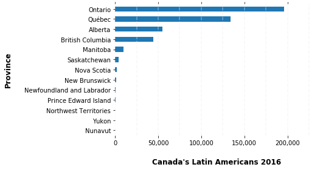

```python
#use matplotlib to convert the province today to a barchart for visualization
bar_prov = prov_df2.sort_values('Latin_Americans_2016', ascending=True).set_index('Province')

bar_prov = bar_prov.plot(kind='barh')

#despine
bar_prov.spines['right'].set_visible(False)
bar_prov.spines['top'].set_visible(False)
bar_prov.spines['left'].set_visible(False)
bar_prov.spines['bottom'].set_visible(False)
#switch off ticks
bar_prov.tick_params(axis='both', which='both', bottom='off', top='on', labelleft='on', labelbottom='on')

#set x-axis
vals = bar_prov.get_xticks()
for tick in vals:
    bar_prov.axvline(x=tick, linestyle='dashed', alpha=0.4, color='#eeeeee', zorder=1)

# Set x-axis label
bar_prov.set_xlabel("Canada's Latin Americans 2016", labelpad=20, weight='bold', size=12)

# Set y-axis label
bar_prov.set_ylabel('Province', labelpad=20, weight='bold', size=12)

# Format y-axis label
bar_prov.xaxis.set_major_formatter(StrMethodFormatter('{x:,g}'))

bar_prov.get_legend().remove()
bar_prov
```

# **Methodology** section 2:

According to Canada's 2016 census Ontario has the largest population at 196K. This would make Ontario an ideal location for Latinos seeking to immigrate to Canada.

**Description of Applications**

> - **foursquare API** to search for venues In Toronto that cater to Latin American's, using keywords ("Latin" and "Mexican")
> - **geopy** to locate the coordinates (latitude, longitude) for Toronto, ON
> - **folium plotting library** to visualize the the latin locations

### **Where to find Latin Venues**

```python
#Apply Foursquare API credentials
CLIENT_ID = 'REMOVED' # your Foursquare ID
CLIENT_SECRET = 'REMOVED' # your Foursquare Secret
VERSION = '20200804'
LIMIT = 150
```

```python
#find Toronto Latitude and Longitude
address = 'Toronto, ON'

geolocator = Nominatim(user_agent="foursquare_agent")
location = geolocator.geocode(address)
latitude = location.latitude
longitude = location.longitude
```

```python
#first search for any venue with word Mexican within a 5000 radius
search_query = 'Mexican'
radius = 5000

#get url
url = 'https://api.foursquare.com/v2/venues/search?client_id={}&client_secret={}&ll={},{}&v={}&query={}&radius={}&limit={}'.format(CLIENT_ID, CLIENT_SECRET, latitude, longitude, VERSION, search_query, radius, LIMIT)

#get resluts
results = requests.get(url).json()

# assign relevant part of JSON to venues
venues = results['response']['venues']

# tranform venues into a dataframe
Latin_DF = json_normalize(venues)
```

```python
#second search for any venue with word Latin within a 5000 radius
search_query1 = 'Latin'
radius1 = 5000

#get url
url1 = 'https://api.foursquare.com/v2/venues/search?client_id={}&client_secret={}&ll={},{}&v={}&query={}&radius={}&limit={}'.format(CLIENT_ID, CLIENT_SECRET, latitude, longitude, VERSION, search_query1, radius1, LIMIT)

#get results
results1 = requests.get(url1).json()

# assign relevant part of JSON to venues
venues1 = results1['response']['venues']

# tranform venues into a dataframe
Latin_DF1 = json_normalize(venues1)
```

```python
# third append the two dataframes
Latin_DF2 = Latin_DF1.append(Latin_DF, ignore_index = True)
```

```python
# keep only columns that include venue name, and anything that is associated with location
filtered_columns = ['name', 'categories'] + [col for col in Latin_DF2.columns if col.startswith('location.')] + ['id']
Latin_DF_filtered = Latin_DF2.loc[:, filtered_columns]

# function that extracts the category of the venue
def get_category_type(row):
    try:
        categories_list = row['categories']
    except:
        categories_list = row['venue.categories']

    if len(categories_list) == 0:
        return None
    else:
        return categories_list[0]['name']

# filter the category for each row
Latin_DF_filtered['categories'] = Latin_DF_filtered.apply(get_category_type, axis=1)

# clean column names by keeping only last term
Latin_DF_filtered.columns = [column.split('.')[-1] for column in Latin_DF_filtered.columns]
```

```python
#Reset index and clean data
Lat_df = Latin_DF_filtered.reset_index()
Lat_df = Lat_df[['name', 'categories', 'lat', 'lng', 'postalCode']]

Lat_df['Postal Code'] = Lat_df.loc[:, ('postalCode')].str[:3]

Lat_df.drop(['postalCode'], axis=1, inplace=True)
```

```python
venues_map = folium.Map(location=[latitude, longitude], zoom_start=15) # generate map centred Toronto

# add a red circle marker to represent the Conrad Hotel
folium.features.CircleMarker(
    [latitude, longitude],
    radius=10,
    color='red',
    popup='Toronto Center',
    fill = True,
    fill_color = 'red',
    fill_opacity = 0.6
).add_to(venues_map)

# add the latin locations as blue circle markers
for lat, lng, label in zip(Lat_df.lat, Lat_df.lng, Lat_df.categories):
    folium.features.CircleMarker(
        [lat, lng],
        radius=5,
        color='blue',
        popup=label,
        fill = True,
        fill_color='blue',
        fill_opacity=0.6
    ).add_to(venues_map)

# display map
venues_map
```

Make this Notebook Trusted to load map: File -> Trust Notebook

[interactive chart not shown]

# **Methodology** section 3:

**Description of Applications**

> - **BeautifulSoup** Python package to extract Toronto Neighborhoods and Boroughs to determine neighborhoods with the largest amount of Latin venues. Then Categorize the venues
> - **geopy** to locate the coordinates (latitude, longitude)

```python
#scrape the Wikipedia https://en.wikipedia.org/wiki/List_of_postal_codes_of_Canada:_M
url = 'https://en.wikipedia.org/wiki/List_of_postal_codes_of_Canada:_M'
html = urlopen(url).read().decode('utf-8')
tables = BeautifulSoup(html, 'html.parser')
```

```python
#wrangle the data
tables = tables.find('table')
data = tables.find_all('td')

postal_code = []
borough= []
neighborhood = []

for i in range(0, len(data), 3):
    postal_code.append(data[i].text.strip())
    borough.append(data[i+1].text.strip())
    neighborhood.append(data[i+2].text.strip())

toronto_df = pd.DataFrame(data=[postal_code, borough, neighborhood]).transpose()
toronto_df.columns = ['Postal Code', 'Borough', 'Neighborhood']
```

```python
#clean data
toronto_df['Borough'].replace('Not assigned', np.nan, inplace=True)
toronto_df['Neighborhood'].replace('Not assigned', np.nan, inplace=True)
toronto_df.dropna(subset=['Borough'], inplace=True)
```

```python
#copy datafrom to use in section 4
toronto_df1 = toronto_df
```

```python
#get geospacial data for Toronto
toronto_geo_url = "https://cocl.us/Geospatial_data"
toronto_geo_data = pd.read_csv(toronto_geo_url)
```

```python
#merge wiki data and geo data

toronto_df = pd.merge(toronto_df, toronto_geo_data, on='Postal Code')
```

```python
#copy of data frame to be used in section 4
toronto_data = toronto_df
```

```python
#merge latin venus DF andn Neighoborhood df
toronto_df = pd.merge(toronto_df, Lat_df, on='Postal Code')
```

```python
toronto_dfnew = toronto_df.groupby(['Borough', 'categories', 'Neighborhood'])['Postal Code'].count().reset_index()
```

```python
toronto_dfnew.rename(columns={'Postal Code': 'Category Count'})
```

|  | Borough | categories | Neighborhood | Category Count |
| --- | --- | --- | --- | --- |
| 0 | Downtown Toronto | Festival | Regent Park, Harbourfront | 1 |
| 1 | Downtown Toronto | Latin American Restaurant | Kensington Market, Chinatown, Grange Park | 2 |
| 2 | Downtown Toronto | Mexican Restaurant | CN Tower, King and Spadina, Railway Lands, Har... | 3 |
| 3 | Downtown Toronto | Mexican Restaurant | Garden District, Ryerson | 3 |
| 4 | Downtown Toronto | Mexican Restaurant | Harbourfront East, Union Station, Toronto Islands | 2 |
| 5 | Downtown Toronto | Mexican Restaurant | Richmond, Adelaide, King | 1 |
| 6 | Downtown Toronto | Mexican Restaurant | St. James Town | 1 |
| 7 | Downtown Toronto | Mexican Restaurant | University of Toronto, Harbord | 1 |
| 8 | Downtown Toronto | Miscellaneous Shop | Kensington Market, Chinatown, Grange Park | 1 |
| 9 | Downtown Toronto | Office | Church and Wellesley | 1 |
| 10 | Downtown Toronto | Tex-Mex Restaurant | CN Tower, King and Spadina, Railway Lands, Har... | 1 |
| 11 | East Toronto | Event Service | The Danforth West, Riverdale | 1 |
| 12 | East Toronto | Mexican Restaurant | Studio District | 1 |
| 13 | North York | Food Court | Humber Summit | 1 |
| 14 | West Toronto | Mexican Restaurant | Brockton, Parkdale Village, Exhibition Place | 1 |
| 15 | West Toronto | Mexican Restaurant | Little Portugal, Trinity | 2 |
| 16 | West Toronto | Mexican Restaurant | Parkdale, Roncesvalles | 1 |
| 17 | York | Mexican Restaurant | Humewood-Cedarvale | 2 |
| 18 | York | Taco Place | Caledonia-Fairbanks | 1 |

# **Methodology** section 4:

**Description of Applications**

```python
# Select first Neighborhood toronto:
to_lat = toronto_data.loc[0, 'Latitude']
to_long = toronto_data.loc[0, 'Longitude']

to_name = toronto_data.loc[0, 'Neighborhood']
radius=750
LIMIT=100

print('Latitude and Longitude values of {} are {}, {}'.format(to_name,
                                                               to_lat,
                                                               to_long))
```

```
Latitude and Longitude values of Parkwoods are 43.7532586, -79.3296565
```

```python
url4 = 'https://api.foursquare.com/v2/venues/explore?&client_id={}&client_secret={}&v={}&ll={},{}&radius={}&limit={}'.format(
    CLIENT_ID,
    CLIENT_SECRET,
    VERSION,
    to_lat,
    to_long,
    radius,
    LIMIT)
results4 = requests.get(url4).json()
```

```python
venues4 = results4['response']['groups'][0]['items']
nearby_venues = json_normalize(venues4)
```

```python
# function that extracts the category of the venue
def get_category_type4(row):
    try:
        categories_list4 = row['categories']
    except:
        categories_list4 = row['venue.categories']

    if len(categories_list4) == 0:
        return None
    else:
        return categories_list4[0]['name']
```

**Clean the JSON and Structure to Create the Dataframe**

```python
venues4 = results4['response']['groups'][0]['items']

nearby_venues = json_normalize(venues4) # flatten JSON

# filter columns
filtered_columns4 = ['venue.name', 'venue.categories', 'venue.location.lat', 'venue.location.lng']
nearby_venues =nearby_venues.loc[:, filtered_columns4]

# filter the category for each row
nearby_venues['venue.categories'] = nearby_venues.apply(get_category_type4, axis=1)

# clean columns
nearby_venues.columns = [col.split(".")[-1] for col in nearby_venues.columns]
```

**Explore Nearby Neighborhoods in Toronto**

```python
def getNearbyVenues(names, latitudes, longitudes, radius=500):

    venues_list=[]
    for name, lat, lng in zip(names, latitudes, longitudes):
        print(name)

        # create the API request URL
        url4 = 'https://api.foursquare.com/v2/venues/explore?&client_id={}&client_secret={}&v={}&ll={},{}&radius={}&limit={}'.format(
            CLIENT_ID,
            CLIENT_SECRET,
            VERSION,
            lat,
            lng,
            radius,
            LIMIT)

        # make the GET request
        results4 = requests.get(url4).json()["response"]['groups'][0]['items']

        # return only relevant information for each nearby venue
        venues_list.append([(
            name,
            lat,
            lng,
            v['venue']['name'],
            v['venue']['location']['lat'],
            v['venue']['location']['lng'],
            v['venue']['categories'][0]['name']) for v in results4])

    nearby_venues = pd.DataFrame([item for venue_list in venues_list for item in venue_list])
    nearby_venues.columns = ['Neighborhood',
                  'Neighborhood Latitude',
                  'Neighborhood Longitude',
                  'Venue',
                  'Venue Latitude',
                  'Venue Longitude',
                  'Venue Category']

    return(nearby_venues)
```

```python
toronto_venues = getNearbyVenues(names=toronto_data['Neighborhood'],
                                   latitudes=toronto_data['Latitude'],
                                   longitudes=toronto_data['Longitude']
                                  )
```

```
Parkwoods
Victoria Village
Regent Park, Harbourfront
Lawrence Manor, Lawrence Heights
Queen's Park, Ontario Provincial Government
Islington Avenue, Humber Valley Village
Malvern, Rouge
Don Mills
Parkview Hill, Woodbine Gardens
Garden District, Ryerson
Glencairn
West Deane Park, Princess Gardens, Martin Grove, Islington, Cloverdale
Rouge Hill, Port Union, Highland Creek
Don Mills
Woodbine Heights
St. James Town
Humewood-Cedarvale
Eringate, Bloordale Gardens, Old Burnhamthorpe, Markland Wood
Guildwood, Morningside, West Hill
The Beaches
Berczy Park
Caledonia-Fairbanks
Woburn
Leaside
Central Bay Street
Christie
Cedarbrae
Hillcrest Village
Bathurst Manor, Wilson Heights, Downsview North
Thorncliffe Park
Richmond, Adelaide, King
Dufferin, Dovercourt Village
Scarborough Village
Fairview, Henry Farm, Oriole
Northwood Park, York University
East Toronto, Broadview North (Old East York)
Harbourfront East, Union Station, Toronto Islands
Little Portugal, Trinity
Kennedy Park, Ionview, East Birchmount Park
Bayview Village
```

[output cut: 48 more lines]

```
New Toronto, Mimico South, Humber Bay Shores
South Steeles, Silverstone, Humbergate, Jamestown, Mount Olive, Beaumond Heights, Thistletown, Albion Gardens
Steeles West, L'Amoreaux West
Rosedale
Stn A PO Boxes
Alderwood, Long Branch
Northwest, West Humber - Clairville
Upper Rouge
St. James Town, Cabbagetown
First Canadian Place, Underground city
The Kingsway, Montgomery Road, Old Mill North
Church and Wellesley
Business reply mail Processing Centre, South Central Letter Processing Plant Toronto
Old Mill South, King's Mill Park, Sunnylea, Humber Bay, Mimico NE, The Queensway East, Royal York South East, Kingsway Park South East
Mimico NW, The Queensway West, South of Bloor, Kingsway Park South West, Royal York South West
```

**Get the number of rows (size) of the Dataframe**

```python
print(toronto_venues.shape)
toronto_venues.head()
```

```
(2162, 7)
```

|  | Neighborhood | Neighborhood Latitude | Neighborhood Longitude | Venue | Venue Latitude | Venue Longitude | Venue Category |
| --- | --- | --- | --- | --- | --- | --- | --- |
| 0 | Parkwoods | 43.753259 | -79.329656 | Brookbanks Park | 43.751976 | -79.332140 | Park |
| 1 | Parkwoods | 43.753259 | -79.329656 | Sun Life | 43.754760 | -79.332783 | Construction & Landscaping |
| 2 | Parkwoods | 43.753259 | -79.329656 | Variety Store | 43.751974 | -79.333114 | Food & Drink Shop |
| 3 | Victoria Village | 43.725882 | -79.315572 | Victoria Village Arena | 43.723481 | -79.315635 | Hockey Arena |
| 4 | Victoria Village | 43.725882 | -79.315572 | Portugril | 43.725819 | -79.312785 | Portuguese Restaurant |

**Use groupby count to get the number of venues for each neighborhood**

```python
toronto_venues.groupby('Neighborhood').count()
```

| Neighborhood | Neighborhood Latitude | Neighborhood Longitude | Venue | Venue Latitude | Venue Longitude | Venue Category |
| --- | --- | --- | --- | --- | --- | --- |
| Agincourt | 5 | 5 | 5 | 5 | 5 | 5 |
| Alderwood, Long Branch | 8 | 8 | 8 | 8 | 8 | 8 |
| Bathurst Manor, Wilson Heights, Downsview North | 23 | 23 | 23 | 23 | 23 | 23 |
| Bayview Village | 4 | 4 | 4 | 4 | 4 | 4 |
| Bedford Park, Lawrence Manor East | 27 | 27 | 27 | 27 | 27 | 27 |
| ... | ... | ... | ... | ... | ... | ... |
| Willowdale, Willowdale East | 34 | 34 | 34 | 34 | 34 | 34 |
| Willowdale, Willowdale West | 6 | 6 | 6 | 6 | 6 | 6 |
| Woburn | 3 | 3 | 3 | 3 | 3 | 3 |
| Woodbine Heights | 6 | 6 | 6 | 6 | 6 | 6 |
| York Mills West | 2 | 2 | 2 | 2 | 2 | 2 |

96 rows × 6 columns

**Get number of Unique Categories**

```python
print('There are {} uniques categories.'.format(len(toronto_venues['Venue Category'].unique())))
```

```
There are 272 uniques categories.
```

### **Analyze Each Neighborhood**

```python
#Analyze Each Neighborhood

# one hot encoding
toronto_onehot = pd.get_dummies(toronto_venues[['Venue Category']], prefix="", prefix_sep="")

# add neighborhood column back to dataframe
toronto_onehot['Neighborhood'] = toronto_venues['Neighborhood']

# move neighborhood column to the first column
fixed_columns1 = [toronto_onehot.columns[-1]] + list(toronto_onehot.columns[:-1])
toronto_onehot = toronto_onehot[fixed_columns1]

toronto_onehot.head()
```

|  | Yoga Studio | Accessories Store | Afghan Restaurant | Airport | Airport Food Court | Airport Lounge | Airport Service | Airport Terminal | American Restaurant | Antique Shop | ... | Trail | Train Station | Vegetarian / Vegan Restaurant | Video Game Store | Video Store | Vietnamese Restaurant | Warehouse Store | Wine Bar | Wings Joint | Women's Store |
| --- | --- | --- | --- | --- | --- | --- | --- | --- | --- | --- | --- | --- | --- | --- | --- | --- | --- | --- | --- | --- | --- |
| 0 | 0 | 0 | 0 | 0 | 0 | 0 | 0 | 0 | 0 | 0 | ... | 0 | 0 | 0 | 0 | 0 | 0 | 0 | 0 | 0 | 0 |
| 1 | 0 | 0 | 0 | 0 | 0 | 0 | 0 | 0 | 0 | 0 | ... | 0 | 0 | 0 | 0 | 0 | 0 | 0 | 0 | 0 | 0 |
| 2 | 0 | 0 | 0 | 0 | 0 | 0 | 0 | 0 | 0 | 0 | ... | 0 | 0 | 0 | 0 | 0 | 0 | 0 | 0 | 0 | 0 |
| 3 | 0 | 0 | 0 | 0 | 0 | 0 | 0 | 0 | 0 | 0 | ... | 0 | 0 | 0 | 0 | 0 | 0 | 0 | 0 | 0 | 0 |
| 4 | 0 | 0 | 0 | 0 | 0 | 0 | 0 | 0 | 0 | 0 | ... | 0 | 0 | 0 | 0 | 0 | 0 | 0 | 0 | 0 | 0 |

5 rows × 272 columns

```python
toronto_onehot.shape
```

```
(2162, 272)
```

```python
toronto_grouped = toronto_onehot.groupby('Neighborhood').mean().reset_index()
toronto_grouped
```

|  | Neighborhood | Yoga Studio | Accessories Store | Afghan Restaurant | Airport | Airport Food Court | Airport Lounge | Airport Service | Airport Terminal | American Restaurant | ... | Trail | Train Station | Vegetarian / Vegan Restaurant | Video Game Store | Video Store | Vietnamese Restaurant | Warehouse Store | Wine Bar | Wings Joint | Women's Store |
| --- | --- | --- | --- | --- | --- | --- | --- | --- | --- | --- | --- | --- | --- | --- | --- | --- | --- | --- | --- | --- | --- |
| 0 | Agincourt | 0.0 | 0.0 | 0.0 | 0.0 | 0.0 | 0.0 | 0.0 | 0.0 | 0.000000 | ... | 0.0 | 0.0 | 0.0 | 0.0 | 0.000000 | 0.000000 | 0.0 | 0.0 | 0.0 | 0.000000 |
| 1 | Alderwood, Long Branch | 0.0 | 0.0 | 0.0 | 0.0 | 0.0 | 0.0 | 0.0 | 0.0 | 0.000000 | ... | 0.0 | 0.0 | 0.0 | 0.0 | 0.000000 | 0.000000 | 0.0 | 0.0 | 0.0 | 0.000000 |
| 2 | Bathurst Manor, Wilson Heights, Downsview North | 0.0 | 0.0 | 0.0 | 0.0 | 0.0 | 0.0 | 0.0 | 0.0 | 0.000000 | ... | 0.0 | 0.0 | 0.0 | 0.0 | 0.000000 | 0.000000 | 0.0 | 0.0 | 0.0 | 0.000000 |
| 3 | Bayview Village | 0.0 | 0.0 | 0.0 | 0.0 | 0.0 | 0.0 | 0.0 | 0.0 | 0.000000 | ... | 0.0 | 0.0 | 0.0 | 0.0 | 0.000000 | 0.000000 | 0.0 | 0.0 | 0.0 | 0.000000 |
| 4 | Bedford Park, Lawrence Manor East | 0.0 | 0.0 | 0.0 | 0.0 | 0.0 | 0.0 | 0.0 | 0.0 | 0.037037 | ... | 0.0 | 0.0 | 0.0 | 0.0 | 0.000000 | 0.000000 | 0.0 | 0.0 | 0.0 | 0.037037 |
| ... | ... | ... | ... | ... | ... | ... | ... | ... | ... | ... | ... | ... | ... | ... | ... | ... | ... | ... | ... | ... | ... |
| 91 | Willowdale, Willowdale East | 0.0 | 0.0 | 0.0 | 0.0 | 0.0 | 0.0 | 0.0 | 0.0 | 0.000000 | ... | 0.0 | 0.0 | 0.0 | 0.0 | 0.000000 | 0.029412 | 0.0 | 0.0 | 0.0 | 0.000000 |
| 92 | Willowdale, Willowdale West | 0.0 | 0.0 | 0.0 | 0.0 | 0.0 | 0.0 | 0.0 | 0.0 | 0.000000 | ... | 0.0 | 0.0 | 0.0 | 0.0 | 0.000000 | 0.000000 | 0.0 | 0.0 | 0.0 | 0.000000 |
| 93 | Woburn | 0.0 | 0.0 | 0.0 | 0.0 | 0.0 | 0.0 | 0.0 | 0.0 | 0.000000 | ... | 0.0 | 0.0 | 0.0 | 0.0 | 0.000000 | 0.000000 | 0.0 | 0.0 | 0.0 | 0.000000 |
| 94 | Woodbine Heights | 0.0 | 0.0 | 0.0 | 0.0 | 0.0 | 0.0 | 0.0 | 0.0 | 0.000000 | ... | 0.0 | 0.0 | 0.0 | 0.0 | 0.166667 | 0.000000 | 0.0 | 0.0 | 0.0 | 0.000000 |
| 95 | York Mills West | 0.0 | 0.0 | 0.0 | 0.0 | 0.0 | 0.0 | 0.0 | 0.0 | 0.000000 | ... | 0.0 | 0.0 | 0.0 | 0.0 | 0.000000 | 0.000000 | 0.0 | 0.0 | 0.0 | 0.000000 |

96 rows × 272 columns

```python
toronto_grouped.shape
```

```
(96, 272)
```

### **Top Five Most Common Venues**

```python
#get top 5 venues
num_top_venues = 5

for hood in toronto_grouped['Neighborhood']:
    print("----"+hood+"----")
    temp = toronto_grouped[toronto_grouped['Neighborhood'] == hood].T.reset_index()
    temp.columns = ['venue','freq']
    temp = temp.iloc[1:]
    temp['freq'] = temp['freq'].astype(float)
    temp = temp.round({'freq': 2})
    print(temp.sort_values('freq', ascending=False).reset_index(drop=True).head(num_top_venues))
    print('\n')
```

```
----Agincourt----
                       venue  freq
0             Clothing Store   0.2
1                     Lounge   0.2
2               Skating Rink   0.2
3             Breakfast Spot   0.2
4  Latin American Restaurant   0.2


----Alderwood, Long Branch----
            venue  freq
0     Pizza Place  0.25
1        Pharmacy  0.12
2             Pub  0.12
3  Sandwich Place  0.12
4     Coffee Shop  0.12


----Bathurst Manor, Wilson Heights, Downsview North----
                       venue  freq
0                       Bank  0.09
1                Coffee Shop  0.09
2              Shopping Mall  0.04
3  Middle Eastern Restaurant  0.04
4         Frozen Yogurt Shop  0.04


----Bayview Village----
                 venue  freq
0                 Café  0.25
1                 Bank  0.25
2   Chinese Restaurant  0.25
3  Japanese Restaurant  0.25
4  Moroccan Restaurant  0.00


----Bedford Park, Lawrence Manor East----
                venue  freq
0         Pizza Place  0.07
1      Sandwich Place  0.07
```

[output cut: 807 more lines]

```
          venue  freq
0          Park  0.17
1   Curling Ice  0.17
2  Skating Rink  0.17
3    Beer Store  0.17
4   Video Store  0.17


----York Mills West----
                             venue  freq
0                             Park   0.5
1                Convenience Store   0.5
2                      Yoga Studio   0.0
3                    Metro Station   0.0
4  Molecular Gastronomy Restaurant   0.0
```

**Create the Dataframe for most common venues**

```python
def return_most_common_venues(row, num_top_venues):
    row_categories = row.iloc[1:]
    row_categories_sorted = row_categories.sort_values(ascending=False)

    return row_categories_sorted.index.values[0:num_top_venues]
```

```python
num_top_venues = 10

indicators = ['st', 'nd', 'rd']

# create columns according to number of top venues
columns = ['Neighborhood']
for ind in np.arange(num_top_venues):
    try:
        columns.append('{}{} Most Common Venue'.format(ind+1, indicators[ind]))
    except:
        columns.append('{}th Most Common Venue'.format(ind+1))

# create a new dataframe
neighborhoods_venues_sorted = pd.DataFrame(columns=columns)
neighborhoods_venues_sorted['Neighborhood'] = toronto_grouped['Neighborhood']

for ind in np.arange(toronto_grouped.shape[0]):
    neighborhoods_venues_sorted.iloc[ind, 1:] = return_most_common_venues(toronto_grouped.iloc[ind, :], num_top_venues)

neighborhoods_venues_sorted.head()
```

|  | Neighborhood | 1st Most Common Venue | 2nd Most Common Venue | 3rd Most Common Venue | 4th Most Common Venue | 5th Most Common Venue | 6th Most Common Venue | 7th Most Common Venue | 8th Most Common Venue | 9th Most Common Venue | 10th Most Common Venue |
| --- | --- | --- | --- | --- | --- | --- | --- | --- | --- | --- | --- |
| 0 | Agincourt | Lounge | Latin American Restaurant | Skating Rink | Breakfast Spot | Clothing Store | Donut Shop | Diner | Discount Store | Distribution Center | Dog Run |
| 1 | Alderwood, Long Branch | Pizza Place | Skating Rink | Sandwich Place | Gym | Pub | Coffee Shop | Pharmacy | Department Store | Dessert Shop | Dim Sum Restaurant |
| 2 | Bathurst Manor, Wilson Heights, Downsview North | Bank | Coffee Shop | Sushi Restaurant | Frozen Yogurt Shop | Ice Cream Shop | Middle Eastern Restaurant | Supermarket | Deli / Bodega | Mobile Phone Shop | Chinese Restaurant |
| 3 | Bayview Village | Japanese Restaurant | Café | Bank | Chinese Restaurant | Diner | Discount Store | Distribution Center | Dog Run | Doner Restaurant | Women's Store |
| 4 | Bedford Park, Lawrence Manor East | Coffee Shop | Sandwich Place | Restaurant | Italian Restaurant | Pizza Place | Sushi Restaurant | Pharmacy | Butcher | Pub | Café |

**Use k-mean to cluster the neighborhoods**

```python
#cluster
kclusters = 5

toronto_grouped_clustering = toronto_grouped.drop('Neighborhood', 1)

# run k-means clustering
kmeans = KMeans(n_clusters=kclusters, random_state=0).fit(toronto_grouped_clustering)

# check cluster labels generated for each row in the dataframe
kmeans.labels_[0:10]
```

```
array([1, 1, 1, 1, 1, 1, 1, 1, 1, 1])
```

```python
# add clustering labels
neighborhoods_venues_sorted.insert(0, 'Cluster Labels', kmeans.labels_)

toronto_merged = toronto_data

# merge toronto_grouped with toronto_data to add latitude/longitude for each neighborhood
toronto_merged = toronto_merged.join(neighborhoods_venues_sorted.set_index('Neighborhood'), on='Neighborhood')

toronto_merged.head() # check the last columns!
```

|  | Postal Code | Borough | Neighborhood | Latitude | Longitude | Cluster Labels | 1st Most Common Venue | 2nd Most Common Venue | 3rd Most Common Venue | 4th Most Common Venue | 5th Most Common Venue | 6th Most Common Venue | 7th Most Common Venue | 8th Most Common Venue | 9th Most Common Venue | 10th Most Common Venue |
| --- | --- | --- | --- | --- | --- | --- | --- | --- | --- | --- | --- | --- | --- | --- | --- | --- |
| 0 | M3A | North York | Parkwoods | 43.753259 | -79.329656 | 4.0 | Park | Food & Drink Shop | Construction & Landscaping | Doner Restaurant | Dim Sum Restaurant | Diner | Discount Store | Distribution Center | Dog Run | Donut Shop |
| 1 | M4A | North York | Victoria Village | 43.725882 | -79.315572 | 1.0 | Hockey Arena | Coffee Shop | Pizza Place | Portuguese Restaurant | Women's Store | Dessert Shop | Dim Sum Restaurant | Diner | Discount Store | Distribution Center |
| 2 | M5A | Downtown Toronto | Regent Park, Harbourfront | 43.654260 | -79.360636 | 1.0 | Coffee Shop | Pub | Bakery | Park | Café | Theater | Restaurant | Breakfast Spot | Health Food Store | Historic Site |
| 3 | M6A | North York | Lawrence Manor, Lawrence Heights | 43.718518 | -79.464763 | 1.0 | Clothing Store | Accessories Store | Coffee Shop | Miscellaneous Shop | Event Space | Furniture / Home Store | Women's Store | Boutique | Vietnamese Restaurant | Dumpling Restaurant |
| 4 | M7A | Downtown Toronto | Queen's Park, Ontario Provincial Government | 43.662301 | -79.389494 | 1.0 | Coffee Shop | Diner | Yoga Studio | Portuguese Restaurant | Beer Bar | Bar | Bank | Mexican Restaurant | Distribution Center | Sandwich Place |

### **Examine the Clusters**

#### **Cluster 1**

```python
toronto_merged.loc[toronto_merged['Cluster Labels'] == 0, toronto_merged.columns[[1] + list(range(5, toronto_merged.shape[1]))]]
```

|  | Borough | Cluster Labels | 1st Most Common Venue | 2nd Most Common Venue | 3rd Most Common Venue | 4th Most Common Venue | 5th Most Common Venue | 6th Most Common Venue | 7th Most Common Venue | 8th Most Common Venue | 9th Most Common Venue | 10th Most Common Venue |
| --- | --- | --- | --- | --- | --- | --- | --- | --- | --- | --- | --- | --- |
| 11 | Etobicoke | 0.0 | Jewelry Store | Women's Store | Donut Shop | Dim Sum Restaurant | Diner | Discount Store | Distribution Center | Dog Run | Doner Restaurant | Drugstore |

#### **Cluster 2**

```python
toronto_merged.loc[toronto_merged['Cluster Labels'] == 1, toronto_merged.columns[[1] + list(range(5, toronto_merged.shape[1]))]]
```

|  | Borough | Cluster Labels | 1st Most Common Venue | 2nd Most Common Venue | 3rd Most Common Venue | 4th Most Common Venue | 5th Most Common Venue | 6th Most Common Venue | 7th Most Common Venue | 8th Most Common Venue | 9th Most Common Venue | 10th Most Common Venue |
| --- | --- | --- | --- | --- | --- | --- | --- | --- | --- | --- | --- | --- |
| 1 | North York | 1.0 | Hockey Arena | Coffee Shop | Pizza Place | Portuguese Restaurant | Women's Store | Dessert Shop | Dim Sum Restaurant | Diner | Discount Store | Distribution Center |
| 2 | Downtown Toronto | 1.0 | Coffee Shop | Pub | Bakery | Park | Café | Theater | Restaurant | Breakfast Spot | Health Food Store | Historic Site |
| 3 | North York | 1.0 | Clothing Store | Accessories Store | Coffee Shop | Miscellaneous Shop | Event Space | Furniture / Home Store | Women's Store | Boutique | Vietnamese Restaurant | Dumpling Restaurant |
| 4 | Downtown Toronto | 1.0 | Coffee Shop | Diner | Yoga Studio | Portuguese Restaurant | Beer Bar | Bar | Bank | Mexican Restaurant | Distribution Center | Sandwich Place |
| 6 | Scarborough | 1.0 | Fast Food Restaurant | Women's Store | Donut Shop | Dim Sum Restaurant | Diner | Discount Store | Distribution Center | Dog Run | Doner Restaurant | Drugstore |
| ... | ... | ... | ... | ... | ... | ... | ... | ... | ... | ... | ... | ... |
| 96 | Downtown Toronto | 1.0 | Pizza Place | Coffee Shop | Italian Restaurant | Chinese Restaurant | Park | Pub | Bakery | Café | Convenience Store | Restaurant |
| 97 | Downtown Toronto | 1.0 | Coffee Shop | Café | Hotel | Japanese Restaurant | Restaurant | Gym | Seafood Restaurant | Steakhouse | Asian Restaurant | American Restaurant |
| 99 | Downtown Toronto | 1.0 | Coffee Shop | Japanese Restaurant | Sushi Restaurant | Restaurant | Gay Bar | Yoga Studio | Café | Pub | Bubble Tea Shop | Pizza Place |
| 100 | East Toronto | 1.0 | Light Rail Station | Gym / Fitness Center | Auto Workshop | Garden Center | Garden | Fast Food Restaurant | Farmers Market | Comic Shop | Pizza Place | Recording Studio |
| 102 | Etobicoke | 1.0 | Fast Food Restaurant | Burrito Place | Burger Joint | Flower Shop | Social Club | Bakery | Convenience Store | Discount Store | Sandwich Place | Hardware Store |

86 rows × 12 columns

#### **Cluster 3**

```python
toronto_merged.loc[toronto_merged['Cluster Labels'] == 2, toronto_merged.columns[[1] + list(range(5, toronto_merged.shape[1]))]]
```

|  | Borough | Cluster Labels | 1st Most Common Venue | 2nd Most Common Venue | 3rd Most Common Venue | 4th Most Common Venue | 5th Most Common Venue | 6th Most Common Venue | 7th Most Common Venue | 8th Most Common Venue | 9th Most Common Venue | 10th Most Common Venue |
| --- | --- | --- | --- | --- | --- | --- | --- | --- | --- | --- | --- | --- |
| 57 | North York | 2.0 | Fabric Shop | Baseball Field | Dim Sum Restaurant | Diner | Discount Store | Distribution Center | Dog Run | Doner Restaurant | Donut Shop | Falafel Restaurant |
| 101 | Etobicoke | 2.0 | Baseball Field | Women's Store | Dim Sum Restaurant | Diner | Discount Store | Distribution Center | Dog Run | Doner Restaurant | Donut Shop | Falafel Restaurant |

#### **Cluster 4**

```python
toronto_merged.loc[toronto_merged['Cluster Labels'] == 3, toronto_merged.columns[[1] + list(range(5, toronto_merged.shape[1]))]]
```

|  | Borough | Cluster Labels | 1st Most Common Venue | 2nd Most Common Venue | 3rd Most Common Venue | 4th Most Common Venue | 5th Most Common Venue | 6th Most Common Venue | 7th Most Common Venue | 8th Most Common Venue | 9th Most Common Venue | 10th Most Common Venue |
| --- | --- | --- | --- | --- | --- | --- | --- | --- | --- | --- | --- | --- |
| 32 | Scarborough | 3.0 | Playground | Women's Store | Donut Shop | Dim Sum Restaurant | Diner | Discount Store | Distribution Center | Dog Run | Doner Restaurant | Drugstore |

#### **Cluster 5**

```python
toronto_merged.loc[toronto_merged['Cluster Labels'] == 4, toronto_merged.columns[[1] + list(range(5, toronto_merged.shape[1]))]]
```

|  | Borough | Cluster Labels | 1st Most Common Venue | 2nd Most Common Venue | 3rd Most Common Venue | 4th Most Common Venue | 5th Most Common Venue | 6th Most Common Venue | 7th Most Common Venue | 8th Most Common Venue | 9th Most Common Venue | 10th Most Common Venue |
| --- | --- | --- | --- | --- | --- | --- | --- | --- | --- | --- | --- | --- |
| 0 | North York | 4.0 | Park | Food & Drink Shop | Construction & Landscaping | Doner Restaurant | Dim Sum Restaurant | Diner | Discount Store | Distribution Center | Dog Run | Donut Shop |
| 16 | York | 4.0 | Trail | Park | Field | Hockey Arena | Dog Run | Dessert Shop | Dim Sum Restaurant | Diner | Discount Store | Distribution Center |
| 21 | York | 4.0 | Park | Women's Store | Pool | Ethiopian Restaurant | Electronics Store | Eastern European Restaurant | Dumpling Restaurant | Drugstore | Donut Shop | Doner Restaurant |
| 35 | East York | 4.0 | Park | Intersection | Convenience Store | Electronics Store | Eastern European Restaurant | Dumpling Restaurant | Drugstore | Donut Shop | Department Store | Doner Restaurant |
| 52 | North York | 4.0 | Park | Doner Restaurant | Dessert Shop | Dim Sum Restaurant | Diner | Discount Store | Distribution Center | Dog Run | Donut Shop | Gym |
| 64 | York | 4.0 | Park | Convenience Store | Event Space | Ethiopian Restaurant | Electronics Store | Eastern European Restaurant | Dumpling Restaurant | Drugstore | Department Store | Donut Shop |
| 66 | North York | 4.0 | Park | Convenience Store | Event Space | Ethiopian Restaurant | Electronics Store | Eastern European Restaurant | Dumpling Restaurant | Drugstore | Department Store | Donut Shop |
| 85 | Scarborough | 4.0 | Park | Playground | Dog Run | Department Store | Dessert Shop | Dim Sum Restaurant | Diner | Discount Store | Distribution Center | Women's Store |
| 91 | Downtown Toronto | 4.0 | Park | Playground | Trail | Eastern European Restaurant | Dumpling Restaurant | Drugstore | Donut Shop | Doner Restaurant | Electronics Store | Dance Studio |
| 98 | Etobicoke | 4.0 | River | Park | Dog Run | Department Store | Dessert Shop | Dim Sum Restaurant | Diner | Discount Store | Distribution Center | Women's Store |

# **Results and Discussion**

Toronto, the province capital of Ontario is multi-culture. The Latin American Community is rapidly growing. Using Foursquare, BeautifulSoup, Geopy, matplotlib k-mean, clustering and Folium you can wrangle and visualize the Latin Demographics, Latin Venues and overall Toronto Neighborhoods.

Methodology section 1 results: The BeautifulSoup package is used to create a dataframe of the wikipage “Latin American Canadians” population. The program extracts the backend table class from the wikipage for population, enabling data wrangling and clean-up to create a dataframe. Then visualize the data using matplotlib. Though through the dataframe alone you can quickly ascertain that Ontario has the largest Latin American Population, matplotlib bar chart does a better job with illustrating the difference for the consumer of this analysis. Methodology section 2 results: Using foursquare, geopy and folium together to conduct a search of venues within a 5000 radius Toronto then to represent these locations on a folium map was amazing. The consumers of this article will learn that Kensington Neighborhood has cluster of venues that cater to Latin Americans they can also quickly view where in Toronto to find the various locations.

K-means algorithm to partition the venue categories, you can examine the specified 5 clusters. Using the cluster approach, you can confirm that Downtown Toronto does have many Mexican Restaurants, as Mexican Restaurant appeared as the 8th most common venue in cluster 2.

# **Conclusion**

As a Latina who has never visited Canada, I found the results of this research very interesting. The findings will enable other Latin American’s to target areas in Toronto that might cater to their demographic and will also provide other areas of interest to them.

From a Decision Scientist perspective, I see the value in leveraging the many tools available in developing your analysis and putting your story together. I would say that k-mean, clustering, beautifulsoup and folium are tools I now have in my skills toolkit that will be valuable in my work.